# Capstone Project

Erik Emilsson

20 December 2022

*This project is part of the Google Data Analytics Certificate on Coursera and* *the dataset and the fictional problem comes from Track 1 How does a bike-share* *navigate speedy business. I am using R in R-markdown for data import, cleaning* *and visualization as well as the final reporting. R-markdown can do all these* *steps and having everything in one place keeps track of the assumptions and* *steps of the analysis for transparency and reporoducibilty.*

The project will be split up into three parts:

1. Business Task Background
2. Data Import, Exploration, and Cleaning
3. Data Analysis
   1. How are the different bike types used by members and non-members?
   2. How is the trip time different for members and non-members?
   3. How are the bikes used throughout the year?
4. Evaluation and conclusions

# 1.Business Task Background

Cyclist is a bike/share program with over 5,800 bikes and 600 docking stations. Currently there are two types of riders:

1. **casual riders** (those who buy single-ride or full-day passes), and
2. **annual members a.k.a. Cyclistic members**.

The goal is to *maximize the number of annual memberships for the company by* *converting more casual riders to annual members*. Lily Moreno (director of marketing) and the Cyclistic finance analysts have concluded that that annual members are more profitable than casual riders. Before this, Cyclistic have focused on building general awareness and appealing to broad consumer segments.

Currently 8 percent of riders use assistive options (e.g. reclining bikes, hand tricycles, and cargo bikes) while the rest use traditional bikes. Those who use traditional bikes are more likely to be casual riders, but about 30 percent of them use the service to commute to work each day.

Of the the following three questions that will guide the larger scope of the future marketing program, this report will only answer the first question:

- **How do annual members and casual riders use Cyclistic bikes** **differently?**
- Why would casual riders buy Cyclistic annual memberships?
- How can Cyclistic use digital media to influence casual riders to become annual members?

The stakeholders are:

- Lily Moreno, director of marketing and my fictional manager,
- The Cyclistic marketing analytics team (which I am part of), which supports the Cyclistic marketing strategy with data, and
- The Cyclistic executive team that will decide if the recommended marketing program is approved or not.

# 2. Data Import, Exploration, and Cleaning

The dataset that will be used to answer the business task is Cycilstic’s historical trip data for the previous 12 months. The dataset was downloaded from the database in a zip file with a folder for each month , each containing data in CSV-format. The data ranges from October 2021 to September 2022, using ISO date notation (YYYYMMDD). All the datasheets were uploaded into BigQuery from a Google Drive location, and were appended in a single table. The 4 geographical coordinates columns (longitudes and latitudes for start and end stations) were removed as this analysis will not be using them. A CSV file of the results was exported as a CSV file to Google Drive and subsequently imported into R for further cleaning and analysis.

```r
library(tidyverse)
library(skimr)
library(janitor)
library(lubridate)
```

[output not shown]

The data from the CSV files has 9 columns from the start. At first glance the headers need to be changed to be more descriptive and there are missing values in the station names and IDs that need to be considered.

```r
df_1 <- df %>%
  rename(Ride_ID = ride_id) %>%
  rename(Bike_Type = rideable_type) %>%
  rename(Rider_Type = member_casual) %>%
  rename(Start_Time = started_at) %>%
  rename(End_Time = ended_at)
```

```r
skim_without_charts(df_1)
```

Data summary

| Name | df_1 |
| --- | --- |
| Number of rows | 5828235 |
| Number of columns | 9 |
| _______________________ |  |
| Column type frequency: |  |
| character | 9 |
| ________________________ |  |
| Group variables | None |

**Variable type: character**

| skim_variable | n_missing | complete_rate | min | max | empty | n_unique | whitespace |
| --- | --- | --- | --- | --- | --- | --- | --- |
| Ride_ID | 0 | 1.00 | 16 | 16 | 0 | 5828235 | 0 |
| Bike_Type | 0 | 1.00 | 11 | 13 | 0 | 3 | 0 |
| Start_Time | 0 | 1.00 | 23 | 23 | 0 | 4875181 | 0 |
| End_Time | 0 | 1.00 | 23 | 23 | 0 | 4884765 | 0 |
| start_station_name | 895032 | 0.85 | 7 | 64 | 0 | 1591 | 0 |
| start_station_id | 895032 | 0.85 | 3 | 44 | 0 | 1302 | 0 |
| end_station_name | 958227 | 0.84 | 9 | 64 | 0 | 1609 | 0 |
| end_station_id | 958227 | 0.84 | 3 | 44 | 0 | 1309 | 0 |
| Rider_Type | 0 | 1.00 | 6 | 6 | 0 | 2 | 0 |

```r
df_2 <- df_1 %>%
  replace_na(list(start_station_id = 'Missing location ID', end_station_id =
                    'Missing location ID')) %>%
  replace_na(list(start_station_id = 'Missing location Name', end_station_id =
                    'Missing location Name'))
```

There may be many reasons for why there’s missing data, and I will speculate a bit here so I can explain my choice in cleaning. For instance, it could be that there the data wasn’t transmitted properly due to bad connections. There might also be missing data because the bike was parked/thrown somewhere “unofficial” at the end of the ride. Whatever the case, the missing data will be of high importance and thus shouldn’t be removed to be transparent and to be clear where more or better data collection is be needed for more granular insights into locations.

Finally to calculate the start date of the ride and the total travel time.

```r
df_2 <-
  mutate(df_2, Trip_Day = as_date(Start_Time))
```

```r
#as.duration((df_2$Trip_Time_Days),"minutes") <-

df_2 <-
  mutate(df_2, Trip_Time = seconds_to_period(as_datetime(df_2$End_Time)-
           as_datetime(df_2$Start_Time))) %>%
  mutate(df_2, Trip_Time_seconds = as_datetime(df_2$End_Time)-
           as_datetime(df_2$Start_Time)) %>%
  select(Ride_ID,Bike_Type,start_station_name,end_station_name,start_station_id,end_station_id,Rider_Type,Trip_Time, Trip_Time_seconds, Trip_Day)
```

There also appears to be some days are less than 0 for members using electric bikes so these will be removed.

```r
paste(sum(df_2$Trip_Time < 0),"rows with trip times below 0 seconds have been removed.")
```

```
## [1] "108 rows with trip times below 0 seconds have been removed."
```

```r
df_clean <- df_2[df_2$Trip_Time >= 0, ] #removes rows below 0 seconds
rm(df,df_1,df_2) #removes other dataframes to save memory
```

```r
head(df_clean)
```

```
## # A tibble: 6 × 10
##   Ride_ID        Bike_…¹ start…² end_s…³ start…⁴ end_s…⁵ Rider…⁶ Trip_…⁷ Trip_…⁸
##   <chr>          <chr>   <chr>   <chr>   <chr>   <chr>   <chr>   <Perio> <drtn>
## 1 CBB80ED419105… classi… Clark … Paulin… KA1504… TA1309… casual  14M 56S 896 se…
## 2 A39C6F6CC0586… classi… Wood S… Honore… 637     TA1305… member  3M 22S  202 se…
## 3 BDC4AB637EDF9… classi… Oakley… Broadw… KA1504… 13323   member  16M 34S 994 se…
## 4 72DC25B2DD467… classi… LaSall… Clinto… TA1309… WL-012  member  7M 23S  443 se…
## 5 006D3F363CF96… electr… Claren… Broadw… TA1307… 15571   member  12M 21S 741 se…
## 6 FB258EEBE89F4… classi… Sheffi… Stockt… TA1306… 13276   member  9M 20S  560 se…
## # … with 1 more variable: Trip_Day <date>, and abbreviated variable names
## #   ¹Bike_Type, ²start_station_name, ³end_station_name, ⁴start_station_id,
## #   ⁵end_station_id, ⁶Rider_Type, ⁷Trip_Time, ⁸Trip_Time_seconds
```

# 3. Analyzing the Questions

## 3a. How are the different bike types used by members and non-members?

Visualize the counts of rides by bike type and member/casual(non-member):

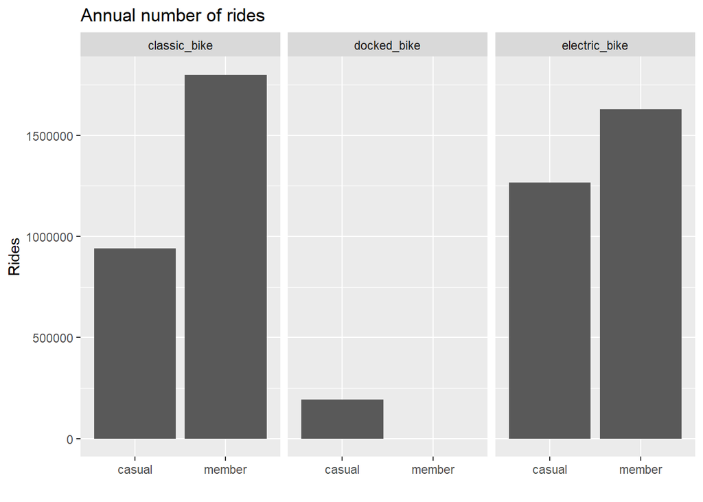

```r
ggplot() +
  geom_bar(df_clean, mapping = aes(Rider_Type)) +
  facet_wrap(~Bike_Type) +
  labs(title="Annual number of rides", x = "", y = "Rides")
```

Some questions that pop up from this first graph are: * Why don’t any annual members use docked bikes at all? Are docked bikes available in the areas where they would be used? What percentage of rides are using docked bikes? * Why do casual riders prefer electric bikes and members prefer classic bikes?

## 3b. How is the trip time different for members and non-members?

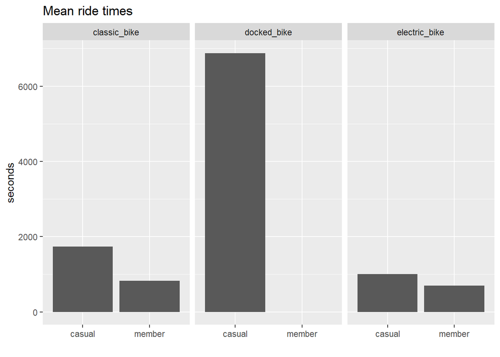

```r
#percentage of riders using docked bikes
df_clean %>%
  group_by(Rider_Type, Bike_Type) %>%
  summarise(mean = mean(Trip_Time_seconds), n= n()) %>%
  ggplot(mapping = aes(x = Rider_Type, y = mean)) +
  geom_bar(stat= "identity") +
  facet_wrap(~Bike_Type) +
  labs(title="Mean ride times", x = "", y = "seconds")
```

Docked bikes seem to include times that are much greater than electric and classic bikes in travel time, so this will be investigated further in a distribution.

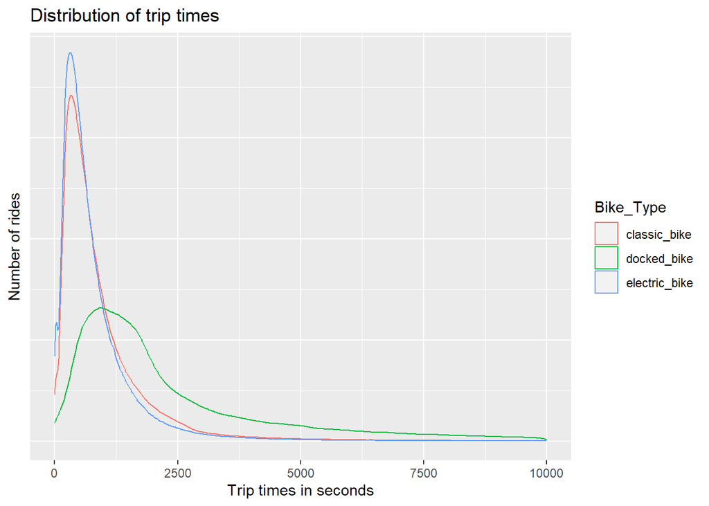

```r
df_clean %>%
  filter(Bike_Type %in% c('classic_bike','docked_bike','electric_bike')) %>%
  ggplot(aes(x=Trip_Time_seconds, color = Bike_Type)) +
  geom_density() +
  scale_x_continuous(limits=c(0, 10000)) +
  labs(title = "Distribution of trip times",
       x = "Trip times in seconds", y = "Number of rides") +
  theme(axis.text.y =element_blank(), axis.ticks.y=element_blank())
```

## 3c. How are the bikes used throughout the year?

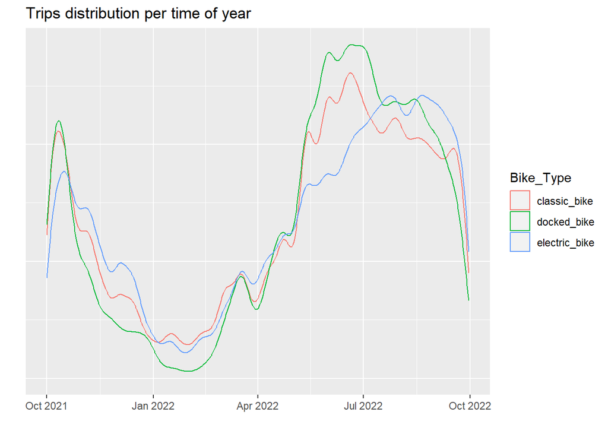

```r
df_clean %>%
  filter(Bike_Type %in% c('classic_bike','docked_bike','electric_bike')) %>%
  ggplot(aes(x=Trip_Day,color = Bike_Type)) +
  geom_density() +
  labs(title = "Trips distribution per time of year",
       x = "", y = "") +
  theme(axis.text.y =element_blank(), axis.ticks.y=element_blank())
```

Bike usage is higher between May-October and lower between September-April.

There is not much difference between what time of year users of different bike types ride bikes except for a dip of relative electric bike usage in June.

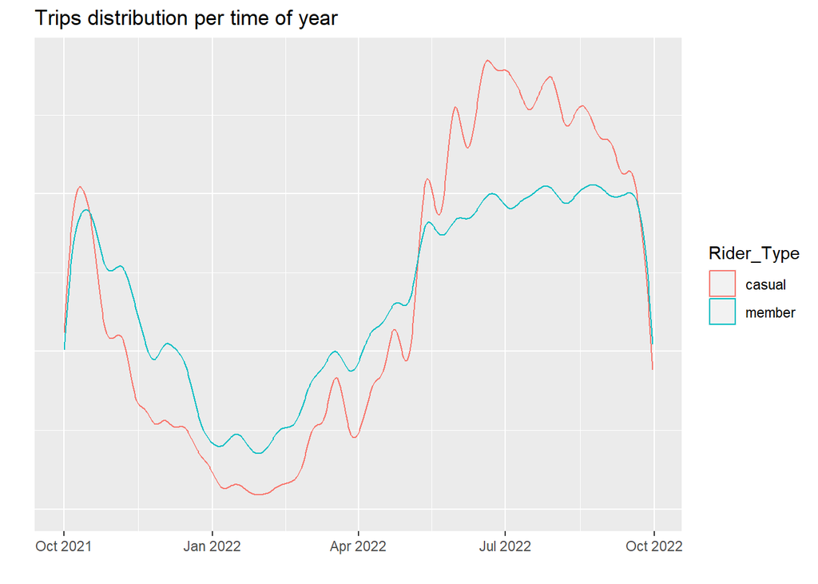

```r
df_clean %>%
  filter(Rider_Type %in% c('casual','member')) %>%
  ggplot(aes(x=Trip_Day, color = Rider_Type)) +
  geom_density() +
  labs(title = "Trips distribution per time of year",
       x = "", y = "") +
  theme(axis.text.y =element_blank(), axis.ticks.y=element_blank())
```

Members have a more even distribution of usage for throughout the year compared to casual riders. Essentially, the cooler months of September-May casual riders use the service less relative to members while in the warmer months June-October they use the bikes more relative to members. The difference is most extreme in June-August.

As the summer months are where most casual riders are using the bikes, there could be an opportunity to run campaigns during these months.

## 4. Evaluation and conclusions

The lack of data on station names (of about 15%) and geographical coordinates (less than 1%) can mean that the results are skewed, especially if the lack of data for these observations are not spread evenly. For example, if there are specific stations that don’t show the data, then there could be a significant difference from the reported and actual number of rides in that area.

# TO DO

I think I could shorten the text by omitting some things that don’t specifically have to do with the business task that I specifically am answering with my analysis. Alternatively use some formatting to make it different from the main text.

I could include the link to the data and be clearer with the problems with the data in a separate section in the Data Import, Exploration, and Cleaning chapter.

I could write an introduction to the analysis phase with how I organized and formatted data for the analysis, including statistical calculations.

I’m most proud of the distribution of trip times, because I felt that it was a simple way of showing that there is a difference for the bike types while also showing how they are different, all in one graph. I think I should look over the graphs again to make sure that the main messages are even clearer by checking the labels again.